# AS01_base_google_trend

洪嘉琪

2026-03-14

```r
# ADD libraries here
library(tidyverse)
library(readxl)
library(RColorBrewer)
```

# AS01 Visualize Google Trends

這份作業將帶領同學學習如何使用 **R Markdown** 來處理 **Google Trends** 下載的數據，並透過**時間序列視覺化**來分析趨勢變化。作業目標不僅包括掌握 **bar chart** 與 **line chart** 的繪製，也希望同學能積極使用 **ChatGPT**、**Claude** 等 AI 工具來協助解決程式撰寫與數據分析過程中的困難。

## Step 1. 下載Google Trend數據

- 前往 Google Trends
- 選擇一組感興趣的關鍵字（至少三個詞、建議用英文詞、關鍵字的搜尋量不要差太多會比較好觀察），設定時間範圍，時間可選「Past 12 months」或「Past 5 years」，下載 CSV 檔案。

## Step 2. 讀取與前處理數據

### 2.1 Read CSV files

- 使用 `read.csv()` 或 `read.table()` 讀取資料。
- 注意：跳過前兩行，因為第一行是類別說明，第二行是空行

```r
# YOUR CODE SHOULD BE HERE
# Google Trends 下載下來的CSV，第一行通常是標題（例如：關鍵字搜尋熱度），第二行才是欄位名稱。如果不加 skip = 2，讀進去的資料會亂掉。
data <- read_csv("data/AS01_multiTimeline03.csv",
                 skip = 2)
# View(data)
head(data)
```

```
## # A tibble: 6 × 5
##   週         `護理之家: (台灣)` `看護: (台灣)` `喘息服務: (台灣)` `輔具: (台灣)`
##   <date>                  <dbl>          <dbl>              <dbl>          <dbl>
## 1 2021-03-14                 51             26                  2             16
## 2 2021-03-21                 54             30                  2             13
## 3 2021-03-28                 46             26                  2             13
## 4 2021-04-04                 48             26                  1             14
## 5 2021-04-11                 53             27                  1             16
## 6 2021-04-18                 48             28                  3             17
```

### 2.2 Cleaning data

- 使用類似將空值取代為0的方法處理數據中的 “<1” 值（將其替換為0.5 或0）

```r
# check if there is any NA
anyNA(data)
```

```
## [1] FALSE
```

### 2.3 Type conversion

- 將第2-4欄（Column）轉換為數值型態（有可能要詢問ChatGPT或Claude）

```r
str(data) # 確認每個關鍵字都已經是 num
```

```
## spc_tbl_ [261 × 5] (S3: spec_tbl_df/tbl_df/tbl/data.frame)
##  $ 週              : Date[1:261], format: "2021-03-14" "2021-03-21" ...
##  $ 護理之家: (台灣): num [1:261] 51 54 46 48 53 48 47 51 53 37 ...
##  $ 看護: (台灣)    : num [1:261] 26 30 26 26 27 28 23 28 25 20 ...
##  $ 喘息服務: (台灣): num [1:261] 2 2 2 1 1 3 2 2 0 1 ...
##  $ 輔具: (台灣)    : num [1:261] 16 13 13 14 16 17 14 21 16 10 ...
##  - attr(*, "spec")=
##   .. cols(
##   ..   週 = col_date(format = ""),
##   ..   `護理之家: (台灣)` = col_double(),
##   ..   `看護: (台灣)` = col_double(),
##   ..   `喘息服務: (台灣)` = col_double(),
##   ..   `輔具: (台灣)` = col_double()
##   .. )
##  - attr(*, "problems")=<externalptr>
```

### 2.4 Renaming columns

- 如果你覺得Column names不太清楚，可以使用以下語法來修改  
  `names(data) <- c("Week", "賴清德", "傅崐萁", "黃國昌")`

```r
colnames(data) <- c("週", "護理之家", "看護", "喘息服務", "輔具")
```

### 2.5 觀察資料

用`head()`印出前五筆數據。

```r
# YOUR CODE SHOULD BE HERE
head(data)
```

```
## # A tibble: 6 × 5
##   週         護理之家  看護 喘息服務  輔具
##   <date>        <dbl> <dbl>    <dbl> <dbl>
## 1 2021-03-14       51    26        2    16
## 2 2021-03-21       54    30        2    13
## 3 2021-03-28       46    26        2    13
## 4 2021-04-04       48    26        1    14
## 5 2021-04-11       53    27        1    16
## 6 2021-04-18       48    28        3    17
```

## Step 3. Bar plot

- 仿照Paid Maternity Leave 的方式用`barplot()`由上而下將每個關鍵字查詢的Timeline繪製為Bar。如果有三組關鍵字，就由上而下三個子圖。
- 注意，如果你使用的是Windows，有可能要調整字型。

```r
Sys.setlocale(category = "LC_ALL", locale = "cht") # Change locale
```

```
## [1] "LC_COLLATE=Chinese_Taiwan.936;LC_CTYPE=Chinese_Taiwan.936;LC_MONETARY=Chinese_Taiwan.936;LC_NUMERIC=C;LC_TIME=Chinese_Taiwan.936"
```

[figure not shown]

```r
# par(family = "STHeitiTC-Light") # Setting Chinese Fonts: Mac
par(mfrow = c(4, 1),
    mar = c(2, 4, 2, 2),
    family = "STKaiti") # margin = 下、左、上、右

my_colors <- brewer.pal(4, "Set2")

# --- 護理之家 ---
barplot(data[["護理之家"]],
        main = "護理之家 Google 搜尋熱度",
        ylab = "搜尋熱度",
        col = my_colors[1],
        space = 0,
        border = NA,
        ylim = c(0, 100))
# --- 看護 ---
barplot(data[["看護"]],
        main = "看護 Google 搜尋熱度",
        ylab = "搜尋熱度",
        col = my_colors[2],
        space = 0,
        border = NA,
        ylim = c(0, 100))
# --- 輔具 ---
barplot(data[["輔具"]],
        main = "輔具 Google 搜尋熱度",
        ylab = "搜尋熱度",
        col = my_colors[3],
        space = 0,
        border = NA,
        ylim = c(0, 100))
# --- 喘息服務 ---
barplot(data[["喘息服務"]],
        main = "喘息服務 Google 搜尋熱度",
        ylab = "搜尋熱度",
        col = my_colors[4],
        space = 0,
        border = NA,
        ylim = c(0, 100))
```

## Step 4. Line Chart

- **折線圖**（Line Chart）：使用 `plot()` 搭配`lines()`建立折線圖。

```r
Sys.setlocale(category = "LC_ALL", locale = "cht") # Change locale
```

```
## [1] "LC_COLLATE=Chinese_Taiwan.936;LC_CTYPE=Chinese_Taiwan.936;LC_MONETARY=Chinese_Taiwan.936;LC_NUMERIC=C;LC_TIME=Chinese_Taiwan.936"
```

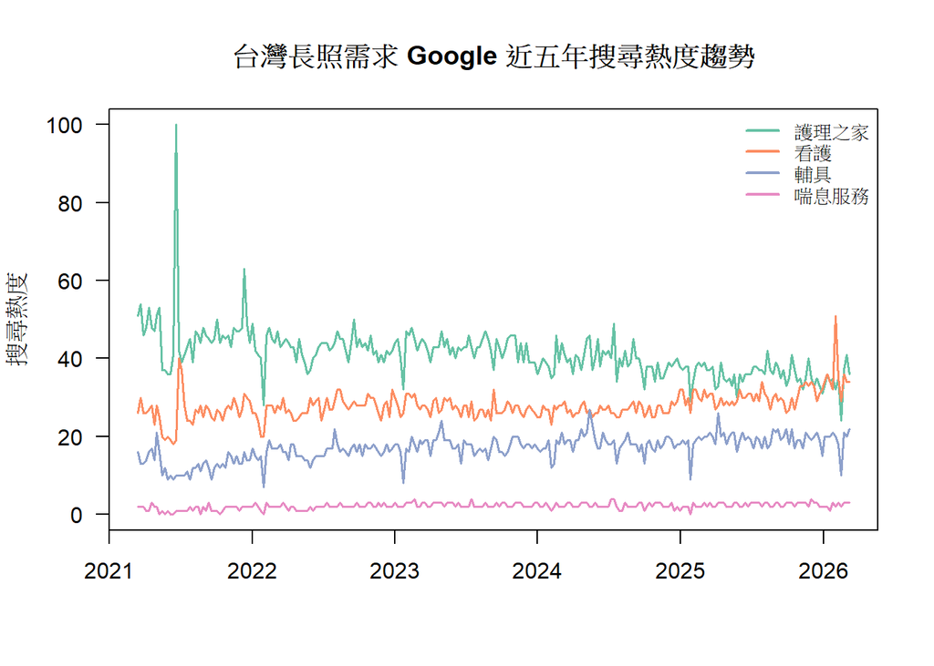

```r
# par(family = "STHeitiTC-Light") # Setting Chinese Fonts: Mac
par(family = "STKaiti") # Setting Chinese Fonts: Windows OK

# plot( ...
# )
# lines(..., col = "blue")
# lines(..., col = "black")

# 1. 第一條線：定義畫布範圍與外框
# xaxt = "n" 是為了先不印 X 軸刻度，等最後再處理
plot(data$週, data$護理之家,
     type = "l",
     col = my_colors[1],
     lwd = 1.5,
     ylim = c(0, 100),
     main = "台灣長照需求 Google 近五年搜尋熱度趨勢",
     xlab = "",
     ylab = "搜尋熱度",
     las = 1)               # las = 1 讓 Y 軸數字轉正
# 2. 疊加其餘四條線
lines(data$週, data$看護,     col = my_colors[2], lwd = 1.5)
lines(data$週, data$輔具,     col = my_colors[3], lwd = 1.5)
lines(data$週, data$喘息服務, col = my_colors[4], lwd = 1.5)

# 3.
legend("topright",
       legend = c("護理之家", "看護", "輔具", "喘息服務"),
       col = my_colors,
       lty = 1,             # 顯示為實線
       lwd = 2,             # 線條粗細
       bty = "n",           # "n" 代表不畫圖例的外框，畫面更乾淨
       cex = 0.8)           # 縮小一點字體以免擋到圖
```